# Html_Uber_Ride_Matching

## Load Data

```python
import pandas as pd
import numpy as np

Events = pd.read_csv('https://storage.googleapis.com/datalynn-datasets/interview-challenge/transportation/Uber_Ride_Matching/Events.csv')
Drivers = pd.read_csv('https://storage.googleapis.com/datalynn-datasets/interview-challenge/transportation/Uber_Ride_Matching/Drivers.csv')
Rides = pd.read_csv('https://storage.googleapis.com/datalynn-datasets/interview-challenge/transportation/Uber_Ride_Matching/Rides.csv')
```

### Question 1

**Demand Surge Analysis:** Using the `Rides` and `Events` tables, determine the percentage increase in ride requests on the days of major events compared to regular days. Can you deduce any patterns about the types of events that cause the highest surge?

**Problem Solving Ideas and Tips:**

**SQL Solution** :

- Extract the date from the `Timestamp` in the `Rides` table.
- Join the `Rides` and `Events` tables on the date.
- Aggregate rides on event days and non-event days.
- Calculate the percentage increase in ride requests on event days compared to non-event days.

```python
import sqlite3

# Create a new SQLite3 connection
conn = sqlite3.connect('uber_data.db')

# Convert pandas dataframes to SQL tables
Rides.to_sql('Rides', conn, if_exists='replace', index=False)
Drivers.to_sql('Drivers', conn, if_exists='replace', index=False)
Events.to_sql('Events', conn, if_exists='replace', index=False)

query = """
WITH EventDayRides AS (
    SELECT DATE(Timestamp) as EventDate, COUNT(Ride_ID) as EventRideCount
    FROM Rides
    JOIN Events ON DATE(Timestamp) = DATE(Event_Date)
    WHERE Event_ID IS NOT NULL
    GROUP BY DATE(Timestamp)
),

RegularDayRides AS (
    SELECT DATE(Timestamp) as RegularDate, COUNT(Ride_ID) as RegularRideCount
    FROM Rides
    LEFT JOIN Events ON DATE(Timestamp) = DATE(Event_Date)
    WHERE Event_ID IS NULL
    GROUP BY DATE(Timestamp)
)

SELECT AVG(EventRideCount) as AverageEventRides, AVG(RegularRideCount) as AverageRegularRides,
       (AVG(EventRideCount) - AVG(RegularRideCount)) / AVG(RegularRideCount) * 100 as PercentageIncrease
FROM EventDayRides, RegularDayRides
"""

result = pd.read_sql(query, conn)
print(result)
```

```
   AverageEventRides  AverageRegularRides  PercentageIncrease
0               24.0                 13.0           84.615385
```

### Question 2

**Efficient Driver Positioning**: Given the patterns observed in the first question, propose a model using the Rides and Drivers tables that would predict areas with high demand on event days. How can we optimally position drivers in these high-demand areas, especially drivers with high ratings and more experience?

**Problem Solving Ideas and Tips:**

1. **Data Preparation**:
   - Combine the `Rides` and `Drivers` tables.
   - Aggregate rides by area on event days.
2. **Modeling**:
   - Use the Elbow Method to identify an optimal number of clusters for K-means clustering.
   - After clustering, interpret the clusters as areas of different demand levels.

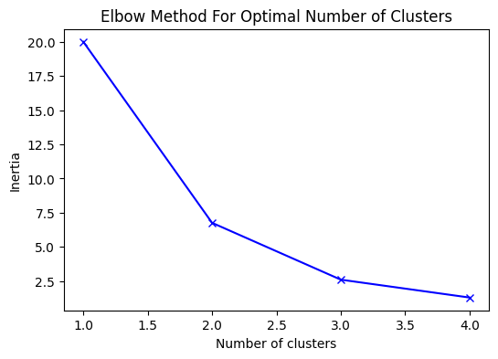

```python
import matplotlib.pyplot as plt
from sklearn.cluster import KMeans
from sklearn.preprocessing import StandardScaler

# Convert 'Event_Date' and 'Timestamp' to datetime format
Events['Event_Date'] = pd.to_datetime(Events['Event_Date'])
Rides['Timestamp'] = pd.to_datetime(Rides['Timestamp'])

# Combine Rides and Drivers tables
combined_df = pd.merge(Rides, Drivers, on="Driver_ID", how="left")

# Filter for event days
event_days = Events['Event_Date'].dt.date
event_rides = combined_df[combined_df['Timestamp'].dt.date.isin(event_days)]

# Aggregate the number of rides per area on event days
area_demand = event_rides.groupby('Origin').size().reset_index(name='Ride_Count')

# Scale the data
X = area_demand[['Ride_Count']]
scaler = StandardScaler()
X_scaled = scaler.fit_transform(X)

# Use the Elbow Method to find optimal number of clusters
inertia = []
K = range(1,5)
for k in K:
    km = KMeans(n_clusters=k, n_init=10)
    km = km.fit(X_scaled)
    inertia.append(km.inertia_)

# Plotting the Elbow Method
plt.figure(figsize=(6,4))
plt.plot(K, inertia, 'bx-')
plt.xlabel('Number of clusters')
plt.ylabel('Inertia')
plt.title('Elbow Method For Optimal Number of Clusters')
plt.show()
```

```
High-demand areas based on clustering: ['Loc_1', 'Loc_10', 'Loc_2', 'Loc_4', 'Loc_6', 'Loc_7']
```

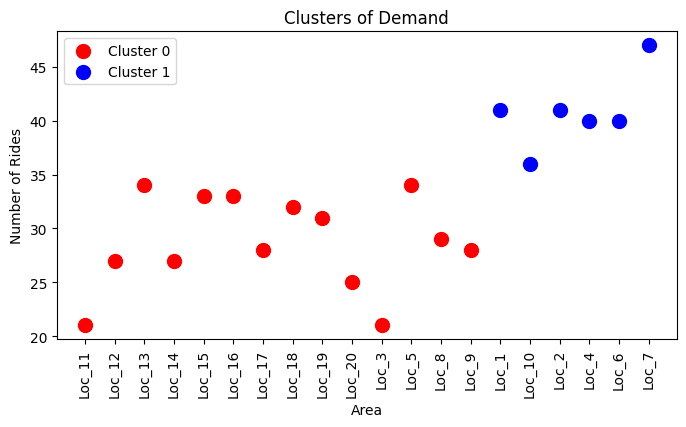

```python
# Set optimal number of cluster base on the graph above
n_clusters = 2
kmeans = KMeans(n_clusters=n_clusters, n_init=10)
area_demand['Cluster'] = kmeans.fit_predict(X_scaled)

# Interpretation: High-demand areas would be the clusters with the highest average Ride_Count
high_demand_cluster = area_demand.groupby('Cluster').mean(numeric_only=True).nlargest(1, 'Ride_Count').index[0]
high_demand_areas = area_demand[area_demand['Cluster'] == high_demand_cluster]['Origin']

print(f"High-demand areas based on clustering: {high_demand_areas.tolist()}")

# Visualize the clusters
plt.figure(figsize=(8,4))
colors = ['red', 'blue']
for i in range(n_clusters):
    plt.scatter(area_demand[area_demand['Cluster'] == i]['Origin'],
                area_demand[area_demand['Cluster'] == i]['Ride_Count'],
                s = 100,
                c = colors[i],
                label = f'Cluster {i}')
plt.xlabel('Area')
plt.xticks(rotation=90)
plt.ylabel('Number of Rides')
plt.legend()
plt.title('Clusters of Demand')
plt.show()
```

**Result Interpretation**:

By analyzing these plots, decisions can be made about where to position drivers, especially those with higher ratings and more experience, to meet demand efficiently.

**Strategies to Incentivize High-Rated and Experienced Drivers:**

**1. Dynamic Bonus System:**

- **Peak Hour Bonus:** Offer a bonus for high-rated and experienced drivers who are active in high-demand areas during event peaks. This bonus can be a fixed amount or a percentage increase based on the fare.
- **Completing a Set Number of Rides:** Offer bonuses for completing a certain number of rides in high-demand areas during peak times. For instance, completing 10 rides in a high-demand area might earn an extra $20.

**2. Priority Access to High-Paying Rides:**

- **Priority Matching:** High-rated and experienced drivers get priority access to longer (and hence more profitable) rides originating from high-demand areas.

**3. Recognition and Rewards:**

- **Driver of the Month:** Recognize the top drivers serving high-demand areas with titles like "Driver of the Month" based on feedback, number of rides, and responsiveness during event peak times.
- **Exclusive Perks:** Offer perks like free car maintenance checks, discounted car cleaning services, or health benefits for drivers consistently serving high-demand areas.

**4. Advanced Booking Access:**

- Allow high-rated and experienced drivers to get access to advanced bookings (rides booked a few hours to days in advance) in high-demand areas, ensuring them a consistent flow of passengers.

**Conclusion:**

Combining monetary incentives with non-monetary benefits and recognition ensures that high-rated and experienced drivers are motivated to serve high-demand areas, especially during peak event hours. This not only enhances the rider experience but also ensures a consistent and high-quality supply of drivers in areas where they are needed the most.

### Question 3

**Route Optimization for Matching:** Riders often have preferred routes. Using the Rides table, can you identify the most common routes taken on event days? How can this information be utilized to match riders with drivers familiar with these routes, ensuring a faster and smoother ride?

**Problem Solving Ideas and Tips:** For each new route, find the driver with the most experience with the route and send them the ride request.

```python
# Sampling 10 event dates randomly from Events DataFrame
sampled_event_dates = Events['Event_Date'].sample(10, random_state=42)

# For each event date, sample a ride from Rides DataFrame
ride_requests = []
for event_date in sampled_event_dates:
    ride_sample = Rides[Rides['Timestamp'].dt.date == event_date.date()].sample(1, random_state=42)
    ride_requests.append(ride_sample)

ride_requests_df = pd.concat(ride_requests, ignore_index=True)

# Drop unnecessary columns and keep only those relevant to the ride request
ride_requests_df = ride_requests_df[['Ride_ID', 'Timestamp', 'Origin', 'Destination']]
ride_requests_df.rename(columns={'Ride_ID': 'RideRequest_ID'}, inplace=True)

# Matching Ride Requests with Best Drivers

best_matched_drivers = []

for _, row in ride_requests_df.iterrows():
    origin = row['Origin']
    destination = row['Destination']

    # Query to find drivers familiar with the route
    matching_query = f"""
    SELECT Driver_ID, COUNT(*) as Frequency
    FROM Rides
    WHERE Origin = '{origin}' AND Destination = '{destination}'
    GROUP BY Driver_ID
    ORDER BY Frequency DESC
    LIMIT 1
    """
    # Note: In the above, I'm assuming you have a `conn` variable which is a connection to your database.
    familiar_driver = pd.read_sql(matching_query, conn)
    best_matched_drivers.append(familiar_driver.iloc[0]['Driver_ID'] if not familiar_driver.empty else None)

ride_requests_df['BestMatched_Driver'] = best_matched_drivers

print("Matching Ride Requests with Best Drivers:")
ride_requests_df
```

```
Matching Ride Requests with Best Drivers:
```

|  | RideRequest_ID | Timestamp | Origin | Destination | BestMatched_Driver |
| --- | --- | --- | --- | --- | --- |
| 0 | 366 | 2023-06-27 23:00:00 | Loc_4 | Loc_16 | 84 |
| 1 | 499 | 2023-07-10 00:00:00 | Loc_2 | Loc_15 | 96 |
| 2 | 460 | 2023-06-29 09:00:00 | Loc_14 | Loc_3 | 75 |
| 3 | 336 | 2023-08-07 03:00:00 | Loc_7 | Loc_1 | 76 |
| 4 | 635 | 2023-06-01 18:00:00 | Loc_1 | Loc_11 | 93 |
| 5 | 752 | 2023-07-04 11:00:00 | Loc_9 | Loc_5 | 90 |
| 6 | 602 | 2023-07-20 20:00:00 | Loc_12 | Loc_16 | 97 |
| 7 | 374 | 2023-07-26 09:00:00 | Loc_5 | Loc_17 | 100 |
| 8 | 612 | 2023-07-06 04:00:00 | Loc_6 | Loc_12 | 77 |
| 9 | 639 | 2023-08-18 23:00:00 | Loc_3 | Loc_5 | 92 |

### Question 4

**Feedback Mechanism for Matching:** With the insights gathered from the previous questions, propose a feedback mechanism embedded within the app. This will allow riders and drivers to provide real-time feedback on the matching process, especially during peak hours on event days.

**Problem Solving Ideas and Tips:**

1. **Feedback Categories:** A robust feedback mechanism will categorize feedback into specific issues. This aids in understanding where the pain points are and makes it easier to aggregate feedback and determine priority areas.
2. **Real-time Analysis:** Immediate feedback, especially during peak hours on event days, can be invaluable. Real-time feedback allows for immediate response and adaptation by the system, potentially improving rider and driver experience within the same event timeframe.
3. **Feedback Validation:** To ensure the feedback system isn't abused, there should be validation methods in place.

**Proposed Feedback Mechanism:**

**1. In-app Feedback Form for Riders and Drivers:**

- **Feedback Categories:** Users (both riders and drivers) can select the category their feedback belongs to. Examples:
  - Route familiarity of driver.
  - Waiting time for driver assignment.
  - Estimated Time of Arrival (ETA) accuracy.
  - App interface and responsiveness during the matching process.
- **Rating System:** A 1-5 star rating for the overall matching experience.
- **Comments Section:** An optional text box for additional comments or suggestions.

**2. Real-time Analysis of Feedback:**

- **Immediate Response Mechanism:** If feedback indicates a critical issue, such as app malfunction during peak hours, immediate notifications are sent to tech support for troubleshooting.
- **Adaptive Systems:** If multiple users provide feedback about route unfamiliarity in a particular area, the system can immediately prioritize drivers with proven experience in that area for matching.

**3. Feedback Validation:**

- **Feedback Limits:** Users can only provide feedback on the matching process once per ride.
- **Feedback Verification:** Feedback that indicates a severe issue (like safety concerns) will prompt a follow-up from customer support for verification and further action.

**Integration with Insights from Previous Questions:**

- **Preferred Routes:** If a rider frequently uses common event day routes (as identified in Q3), the system can proactively ask for feedback about driver familiarity with the route or if they would prefer drivers who've driven that route more frequently.
- **Driver Positioning:** Using insights from Q2, riders can provide feedback on how quickly a driver arrived after being matched, validating or challenging the optimal positioning strategy.

**Conclusion:**

An integrated feedback mechanism within the app helps Uber continually refine its matching algorithm. By encouraging real-time feedback during peak event days, the system can rapidly adapt to user needs, ensuring the best possible experience for both riders and drivers.